# Estimacion

Javier Cara

Noviembre-Diciembre 2018

# 1 Población y muestra

- Tenemos los siguientes datos:

```r
d <- read.table("body.dat.txt")
# peso
altura = d[,24]
# peso de los hombres
alturaH = altura[d[,25] == 1]
```

- con media y desviación típica:

```r
mean(alturaH)
```

```
## [1] 177.7453
```

```r
sd(alturaH)
```

```
## [1] 7.183629
```

- Supongamos que *body.dat.txt* contiene los datos de todos los alumnos de una universidad.
- Supongamos que no tenemos acceso a estos datos.
- Para poder analizar la altura de los varones de esta universidad vamos un día a dicha universidad y medimos a 8 varones elegidos al azar:

```r
set.seed(3)
( muestra = sample(alturaH, size = 8, replace = F) )
```

```
## [1] 171.4 188.0 192.0 197.1 177.8 179.1 183.5 171.2
```

# 2 Modelo estadístico

- Para responder a nuestra pregunta utilizamos un modelo estadístico:
1. Consideramos un modelo probabilístico para la altura. Sea la variable aleatoria *X: altura de un alumno varón*, con distribución de probabilidad:

$$X \sim N(\mu,\sigma)$$

2. Consideramos que la muestra es un conjunto de 8 variables aleatorias independientes con igual distribución:

$$muestra: \{X_1, X_2, \cdots, X_8 \}, \quad X_i \sim N(\mu,\sigma)$$

3. Los datos numéricos que hemos obtenido con los 8 alumnos son una *realización* de las variables aleatorias

## 2.1 Estadísticos y su distribución en el muestreo

- Se llama **estadístico** (y se representa con T) a cualquier valor calculado con la muestra, $T = T(X_1, X_2, \cdots, X_8)$. Por ejemplo:

$$T_1 = max(X_1, X_2, \cdots, X_8)$$

$$T_2 = \frac{X_1 + X_2 + \cdots + X_8}{8}$$

$$T_3 = \sqrt{X_1^2 + X_2^2 + \cdots + X_8^2}$$

- Los estadísticos son variables aleatorias. Su distribución se llaman **distribuciones en el muestreo**.

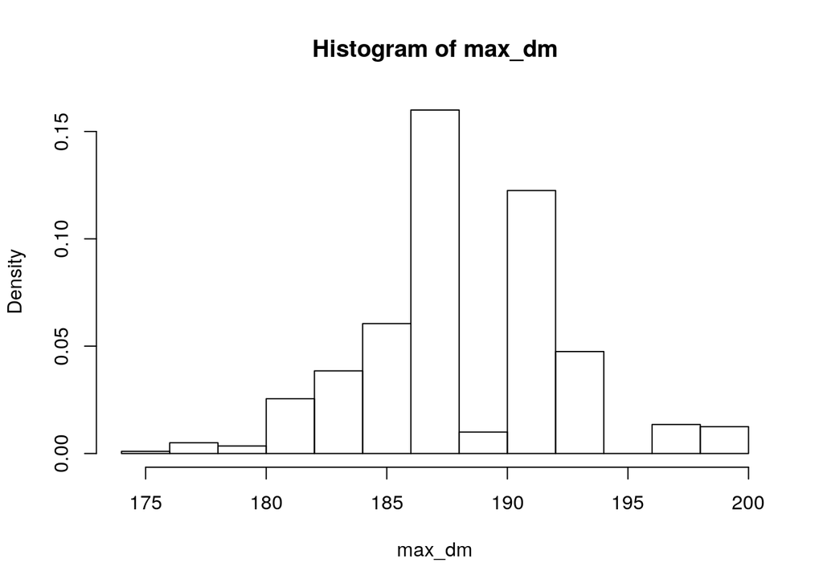

```r
set.seed(3)
# distribución en el muestreo del estadístico T = max(X1, X2,..., X8)
num_rep = 1000
max_dm = rep(0,num_rep)
for (i in 1:num_rep){
  muestra_i = sample(alturaH, size = 8, replace = T)
  max_dm[i] = max(muestra_i)
}
hist(max_dm, freq = F)
```

TEOREMA

Sea $X \sim N(\mu,\sigma)$, y sea $\{X_1, X_2, \cdots, X_n \}$ una muestra de $X$. La distribución en el muestreo del estadístico media muestral es:

$$\frac{X_1 + X_2 + \cdots + X_n}{n} \sim N \left( \mu, \frac{\sigma}{\sqrt{n}} \right)$$

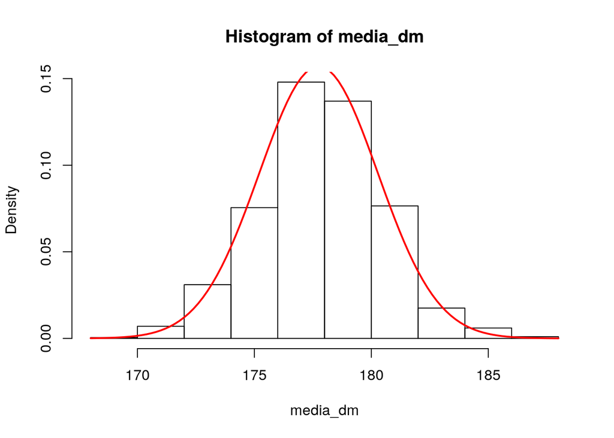

```r
set.seed(3)
# distribución en el muestreo del estadístico T = mean(X1, X2,..., X8)
num_rep = 1000
media_dm = rep(0,num_rep)
for (i in 1:num_rep){
  muestra_i = sample(alturaH, size = 8, replace = T)
  media_dm[i] = mean(muestra_i)
}
hist(media_dm, freq = F)
curve(dnorm(x, mean =  mean(alturaH), sd =  sd(alturaH)/sqrt(8)), add = T, col = "red", lwd = 2 )
```

# 3 Estimación de los parámetros.

## 3.1 Estimación puntual

- Hemos considerado que la altura de los varones tiene distribución $X \sim N(\mu, \sigma)$.
- Nuestro objetivo es calcular $Pr(X \leq 180)$
- Para ello necesitamos conocer $\mu$ y $\sigma$.
- Nuestros datos son la muestra, luego tenemos calcularlos (estimarlos) a partir de la muestra:

TEOREMA

Los estimadores de $\mu$ y $\sigma$ son:

$$\hat \mu = \bar X, \text{ donde } \bar X = \frac{\sum \limits_{i=1}^n X_i}{n}$$

$$\hat \sigma = S, \text{ donde } S^2 = \frac{\sum \limits_{i=1}^n (X_i - \bar X)^2}{n-1}$$

- Según nuestra muestra, los valores que toman los estimadores son:

```r
# estimador de mu
( mu_e = mean(muestra) )
```

```
## [1] 182.5125
```

```r
# estimador de sigma
( sd_e = sd(muestra) )
```

```
## [1] 9.405232
```

## 3.2 Distribución en el muestreo de los estimadores

TEOREMA

La distribución en el muestreo de los estimadores de $\mu$ y $\sigma$ es:

$$\bar X \sim N \left( \mu, \frac{\sigma}{\sqrt{n}} \right)$$

$$\frac{\bar X - \mu}{S/\sqrt{n}} \sim t_{n-1}$$

$$\frac{(n-1)S^2}{\sigma^2} \sim \chi^2_{n-1}$$

- $t_{n-1}$ es la distribución t-student con n-1 grados de libertad:

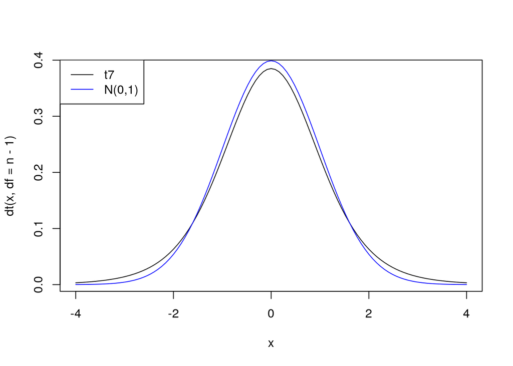

```r
n = 8
curve(dt(x, df = n-1), add = F, from = -4, to = 4)
curve(dnorm(x, 0, 1), add = T, col = "blue")
legend("topleft", legend = c("t7","N(0,1)"), col = c("black","blue"), lty = 1)
```

- $chi^2_{n-1}$ es la distribución chi-cuadrado con n-1 grados de libertad:

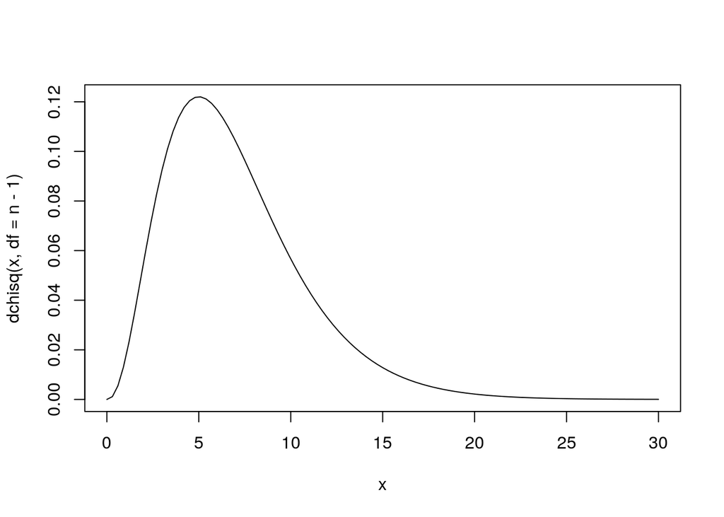

```r
n = 8
curve(dchisq(x, df = n-1), add = F, from = 0, to = 30)
```

## 3.3 Estimación por intervalos

Además de proporcionar un valor para los parámetros, es útil proporcionar un intervalo de valores con alta probabildad de contener al valor estimado. Esto nos da idea de la precisión de la estimación del parámetro.

### 3.3.1 Intervalo de confianza para la media

- En una t-student con 7 grados de libertad se cumple:

```r
qt(0.025, df = 7)
```

```
## [1] -2.364624
```

```r
qt(0.975, df = 7)
```

```
## [1] 2.364624
```

- Por tanto, como el estimador de $\mu$ tiene distribución t-student:

$$\frac{\bar X - \mu}{S/\sqrt{n}} \sim t_{n-1} \Rightarrow Pr \left( -2.36 \leq \frac{\bar X - \mu}{S/\sqrt{8}} \leq 2.36 \right) = 0.95$$

- Despejando

$$Pr \left( \bar X - 2.36\frac{S}{\sqrt{8}} \leq \mu \leq \bar X + 2.36\frac{S}{\sqrt{8}} \right) = 0.95$$

- con los datos de la muestra obtenemos el intervalo de confianza (95%):

```r
n = 8
c(mean(muestra) + qt(0.025, df = n-1)*sd(muestra)/sqrt(n), mean(muestra) + qt(0.975, df = n-1)*sd(muestra)/sqrt(n))
```

```
## [1] 174.6495 190.3755
```

### 3.3.2 Intervalo de confianza para la varianza

- En una chi-cuadrado con 7 grados de libertad se cumple:

```r
qchisq(0.025, df = 7)
```

```
## [1] 1.689869
```

```r
qchisq(0.975, df = 7)
```

```
## [1] 16.01276
```

- Por tanto, como el estimador de $\sigma^2$ tiene distribución chi-quadrado:

$$\frac{(n-1)S^2}{\sigma^2} \sim \chi^2_{n-1} \Rightarrow Pr \left( 1.69 \leq \frac{7S^2}{\sigma^2} \leq 16.01 \right) = 0.95$$

- Despejando

$$Pr \left( \frac{7S^2}{16.01} \leq \sigma^2 \leq \frac{7S^2}{1.69} \right) = 0.95$$

- con los datos de la muestra obtenemos el intervalo de confianza (95%):

```r
n = 8
c((n-1)*var(muestra)/qchisq(0.975, df = n-1), (n-1)*var(muestra)/qchisq(0.025, df = n-1) )
```

```
## [1]  38.6697 366.4241
```

# 4 Ejemplo

La resistencia a compresión (N/mm2) de 15 probetas de hormigón elegidas al azar es:

40.15, 65.10, 49.50, 22.40, 38.20, 60.40, 43.40, 26.35, 31.20, 55.60, 47.25, 73.20, 35.90, 45.25, 52.40

Suponiendo que la resistencia a compresión del hormigón tiene distribución normal, calcular un intervalo de confianza (99%) para la resistencia media y la varianza de la resistencia.

1. Datos

```r
muestra = c(40.15, 65.10, 49.50, 22.40, 38.20, 60.40, 43.40, 26.35, 31.20, 55.60, 47.25, 73.20, 35.90, 45.25, 52.40)
```

2. Modelo

X = “resistencia a compresión del hormigón”, $\ X \sim N(\mu, \sigma)$

3. Intervalo de confianza para $\mu$:

```r
n = 15
c(mean(muestra) + qt(0.01/2, df = n-1)*sd(muestra)/sqrt(n), mean(muestra) + qt(1-0.01/2, df = n-1)*sd(muestra)/sqrt(n))
```

```
## [1] 34.83590 56.67077
```

4. En R, este intervalo se puede calcular directamente con la función *t.test()*:

```r
t.test(muestra, conf.level = 0.99)
```

```
##
##  One Sample t-test
##
## data:  muestra
## t = 12.475, df = 14, p-value = 5.671e-09
## alternative hypothesis: true mean is not equal to 0
## 99 percent confidence interval:
##  34.83590 56.67077
## sample estimates:
## mean of x
##  45.75333
```

5. Intervalo de confianza para $\sigma^2$:

```r
n = 15
c((n-1)*var(muestra)/qchisq(1-0.01/2, df = n-1), (n-1)*var(muestra)/qchisq(0.01/2, df = n-1) )
```

```
## [1]  90.18538 693.19574
```

# 5 Inferencia sobre proporciones

## 5.1 Introduccion

- Se ha realizado una encuesta a 400 personas elegidas al azar para estimar la proporción p de votantes de un partido político. El resultado ha sido:
  - SI: 220
  - NO: 180
- Se desea estimar la proporción de votos que va a obtener dicho partido.

## 5.2 Modelo estadístico para proporciones

$$muestra = \{X_1, X_2, \cdots, X_{400} \}$$
$$X_i = 0, Pr(X_i = 0) = 1-p \\
X_i = 1, Pr(X_i = 1) = p$$
- Este modelo se denomina Bernouilli de parámetro p.

## 5.3 Estimación puntual de la proporción

TEOREMA

Sea $\{X_1, X_2, \cdots, X_{400} \}$ una muestra donde $X_i \sim Bernouilli(p)$. Si hay $n_1$ “unos” y $n_0$ “ceros” enla muestra, entonces el estimador de p es

$$\hat p = \frac{n_1}{n_0 + n_1} = \frac{n_1}{n}$$

- Con los datos numéricos, la estimación de la proporción de votos para el partido político es

```r
n0 = 180
n1 = 220
n = n0 + n1
( p_e = n1/n )
```

```
## [1] 0.55
```

## 5.4 Distribución en el muestreo del estimador de la proporción

TEOREMA

La distribución en el muestreo del estimador de *p* es:

$$\hat{p} \sim N \left( p, \sqrt{\frac{\hat{p}(1-\hat{p})}{n}} \right)$$

## 5.5 Intervalo de confianza

$$\frac{\hat{p} - p}{ \sqrt{\frac{\hat{p}(1-\hat{p})}{n}} } \sim N(0,1) \Rightarrow Pr \left( z_a \leq \frac{\hat{p} - p}{ \sqrt{\frac{\hat{p}(1-\hat{p})}{n}} } \leq z_b \right) = 1-\alpha$$

```r
# zb (por simetría, za = -zb)
alfa = 0.05
qnorm(1-alfa/2)
```

```
## [1] 1.959964
```

- Despejando

$$Pr \left( \hat{p} - z_a \sqrt{ \frac{\hat{p}(1-\hat{p})}{n} } \leq p \leq \hat{p} + z_b \sqrt{ \frac{\hat{p}(1-\hat{p})}{n} } \right) = 1-\alpha$$

```r
c( p_e - qnorm(1-alfa/2)*sqrt(p_e*(1-p_e)/n), p_e + qnorm(1-alfa/2)*sqrt(p_e*(1-p_e)/n) )
```

```
## [1] 0.5012465 0.5987535
```

```r
prop.test(220, 400, conf.level = 0.95, correct = F)
```

```
##
##  1-sample proportions test without continuity correction
##
## data:  220 out of 400, null probability 0.5
## X-squared = 4, df = 1, p-value = 0.0455
## alternative hypothesis: true p is not equal to 0.5
## 95 percent confidence interval:
##  0.5010010 0.5980478
## sample estimates:
##    p
## 0.55
```

## 5.6 Tamaño muestral

- ¿A cuantas personas tengo que preguntar si quiero que el error sea igual al 2%?

$$e = z_b \sqrt{ \frac{\hat{p}(1-\hat{p})}{n} }$$

$$n = z_b^2 \frac{\hat{p}(1-\hat{p})}{e^2}$$

```r
e = 0.02
alfa = 0.05
p_e = 0.55
(n = qnorm(1-alfa/2)^2*p_e*(1-p_e)/e^2)
```

```
## [1] 2376.903
```